# Analisis *American New Cars and Trucks* 2004 Menggunakan *Principal Component Analysis* Dan *Factor Analysis* Dengan RStudio

Achmad Wildan Al Aziz & Rizky Nanda Noverianto

September 7, 2017

# Deskripsi Data

Data yang digunakan adalah data sekunder spesifikasi 428 mobil baru di Amerika pada tahun 2004. Data tersebut merupakan data *American New Cars and Trucks 2004*. Data ini diambil pada hari Sabtu, tanggal 15 April 2017 pukul 16.00 melalui website http://new.censusatschool.org.nz

```r
data1=read.table("D:/Kuliah/AD 2/data.txt", header=T)
datatable(data1)
```

|  | x1 | x2 | x3 | x4 | x5 | x6 | x7 | x8 | x9 | x10 | x11 |
| --- | --- | --- | --- | --- | --- | --- | --- | --- | --- | --- | --- |
| 1 | 11690 | 10965 | 1.6 | 4 | 103 | 8.4 | 6.9 | 1067 | 249 | 424 | 168 |
| 2 | 12585 | 11802 | 1.6 | 4 | 103 | 8.4 | 6.9 | 1057 | 249 | 389 | 168 |
| 3 | 14610 | 13697 | 2.2 | 4 | 140 | 9 | 6.4 | 1178 | 264 | 465 | 175 |
| 4 | 14810 | 13884 | 2.2 | 4 | 140 | 9 | 6.4 | 1204 | 264 | 465 | 173 |
| 5 | 16385 | 15357 | 2.2 | 4 | 140 | 9 | 6.4 | 1178 | 264 | 465 | 175 |
| 6 | 13670 | 12849 | 2 | 4 | 132 | 8.1 | 6.5 | 1161 | 267 | 442 | 170 |
| 7 | 15040 | 14086 | 2 | 4 | 132 | 8.1 | 6.5 | 1182 | 267 | 442 | 170 |
| 8 | 13270 | 12482 | 2 | 4 | 130 | 9 | 7.1 | 1175 | 262 | 427 | 170 |
| 9 | 13730 | 12906 | 2 | 4 | 110 | 8.7 | 6.5 | 1173 | 262 | 427 | 170 |
| 10 | 15460 | 14496 | 2 | 4 | 130 | 9 | 7.1 | 1173 | 262 | 427 | 170 |

[output cut: 418 more lines]

Variabel yang digunakan adalah sebagai berikut

| Variabel | Keterangan |
| --- | --- |
| x1 | *Retail Price* ($US) |
| x2 | *Dealer Cost* ($US) |
| x3 | *Engine Size* (Litres) |
| x4 | *Number of Cylinders* |
| x5 | *Horsepower* (hp) |
| x6 | *City* (km/100L) |
| x7 | *Open Road* (km/100L) |
| x8 | *Weight* (kg) |
| x9 | *Wheel Base* (cm) |
| x10 | *Length* (cm) |
| x11 | *Width* (cm) |

# Eksplorasi Data

Berikut adalah korelasi antar variabel dari data *American New Cars and Trucks* 2004.

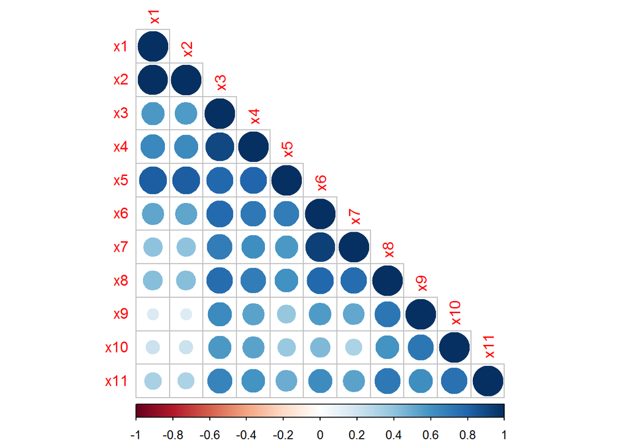

```r
corrplot(cor(data1),type="lower",method="circle")
```

Semua Variabel berkorelasi positif. Variabel X1 dengan x2 berkorelasi paling tinggi. Variabel x1 dengan x9 dan X2 dengan x9 berkorelasi paling rendah.

## x1

Variabel x1 adalah harga yang ditawarkan produsen dan sudah termasuk keuntungan bagi dealer.

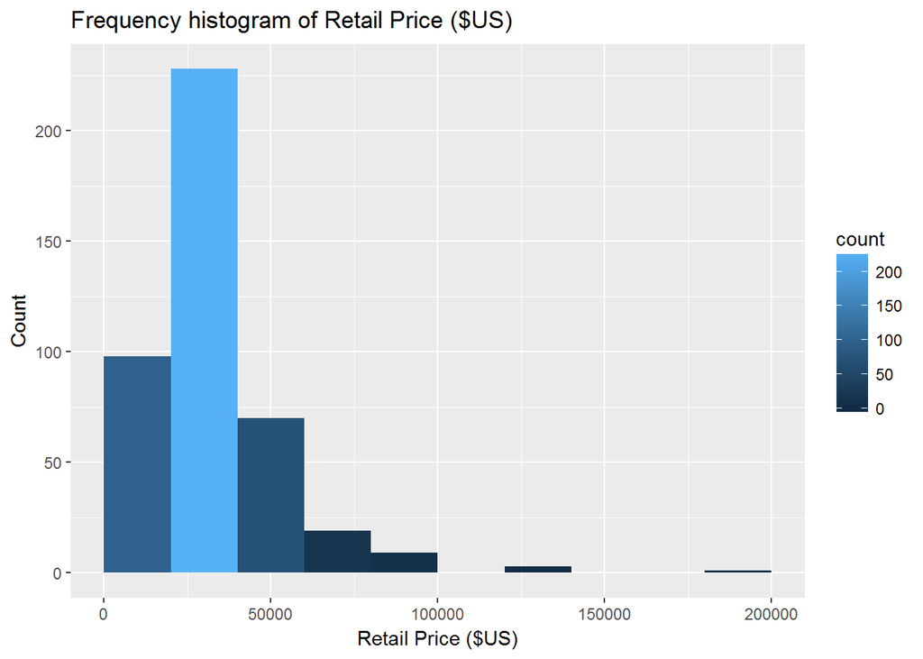

```r
ggplot(data1, aes(data1$x1)) +
    geom_histogram(breaks=seq(0, 200000, by=20000),
                                     aes(fill=..count..)) +
    scale_y_continuous(name = "Count") +
scale_x_continuous(name = "Retail Price ($US)") +
    ggtitle("Frequency histogram of Retail Price ($US)")
```

Tampak histogram *skew kanan*, sehingga variabel X1 tidak berdistribusi normal. Mayoritas produsen memberikan harga sekitar 20000-4000 ($US).

## x2

Biaya yang dibayarkan dealer pada pada produsen.

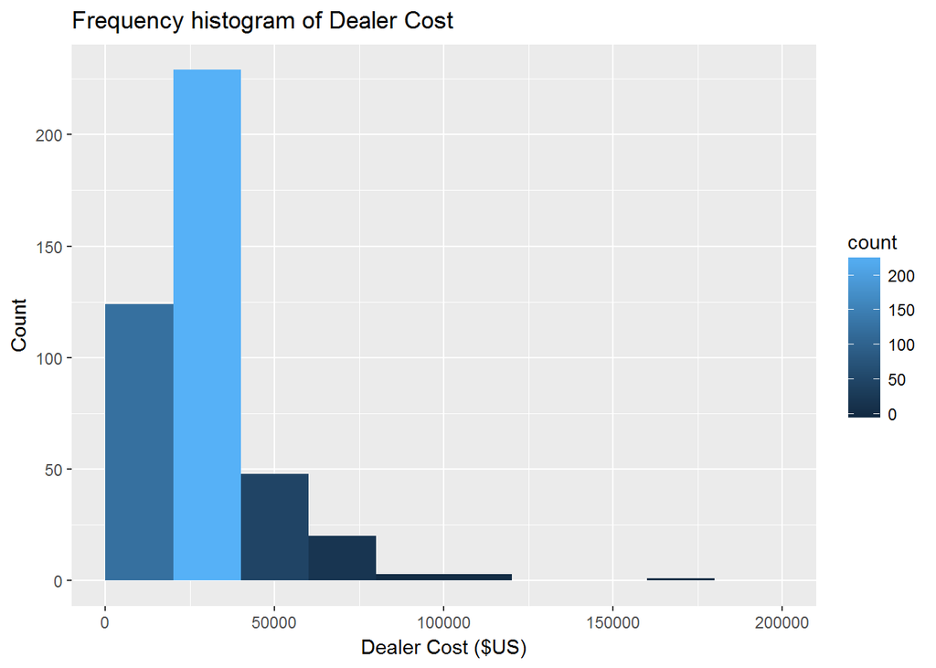

```r
ggplot(data1, aes(data1$x2)) +
    geom_histogram(breaks=seq(0, 200000, by=20000),
                                     aes(fill=..count..)) +
    scale_y_continuous(name = "Count") +
scale_x_continuous(name = "Dealer Cost ($US)") +
    ggtitle("Frequency histogram of Dealer Cost")
```

Tampak histogram *skew kanan*, sehingga variabel X2 tidak berdistribusi normal. Mayoritas dealer harus membayar kepada produsen sebesar 20000-40000 ($US).

## x3

Ukuran kapasitas mesin dalam liter.

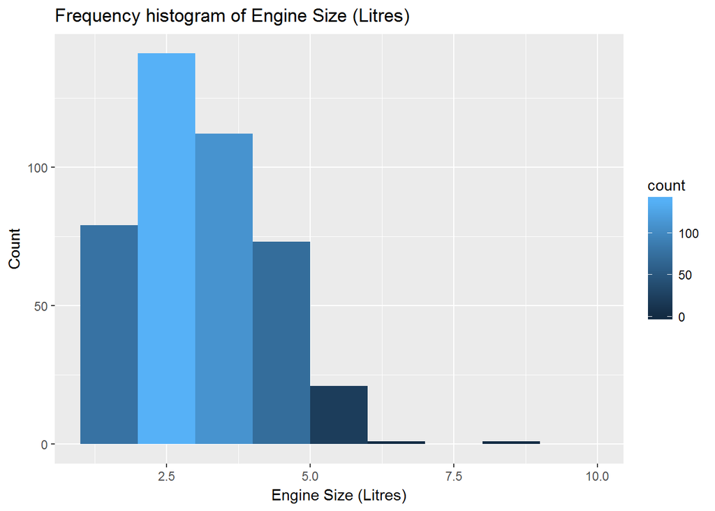

```r
ggplot(data1, aes(data1$x3)) +
    geom_histogram(breaks=seq(1, 10, by=1),
                                     aes(fill=..count..)) +
    scale_y_continuous(name = "Count") +
scale_x_continuous(name = "Engine Size (Litres)") +
    ggtitle("Frequency histogram of Engine Size (Litres)")
```

Tampak histogram *skew kanan*, sehingga variabel X3 tidak berdistribusi normal. Mayoritas mobil memiliki kapasitas mesin 2,5 liter.

## x4

Jumlah silinder pada mobil.

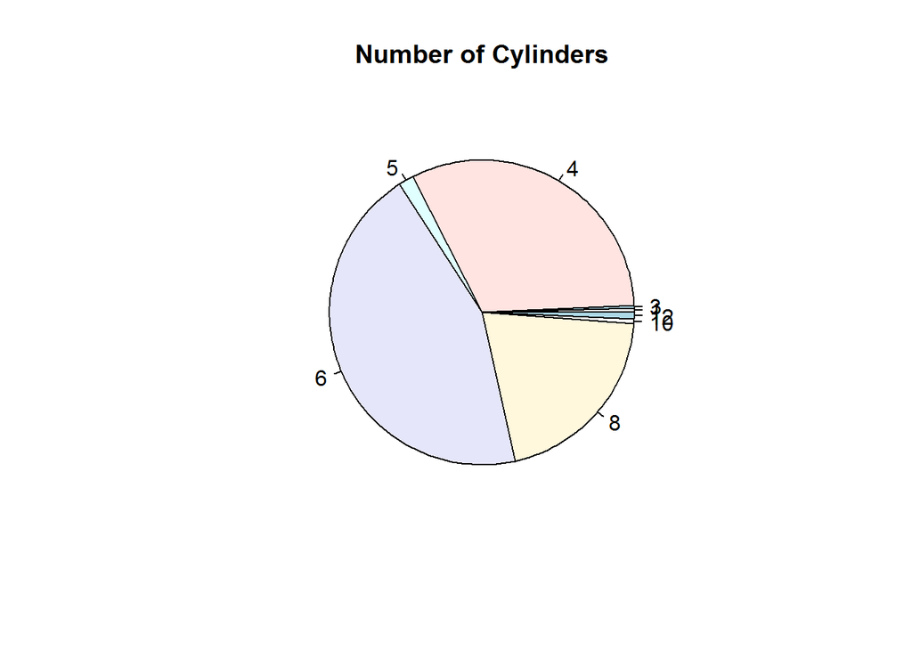

```r
p=as.data.frame(table(data1$x4))
pie(p$Freq,p$Var1,main = "Number of Cylinders")
```

Mayoritas mobil memiliki 6 silinder.

## x5

Tenaga mobil dalam satuan horsepower (hp).

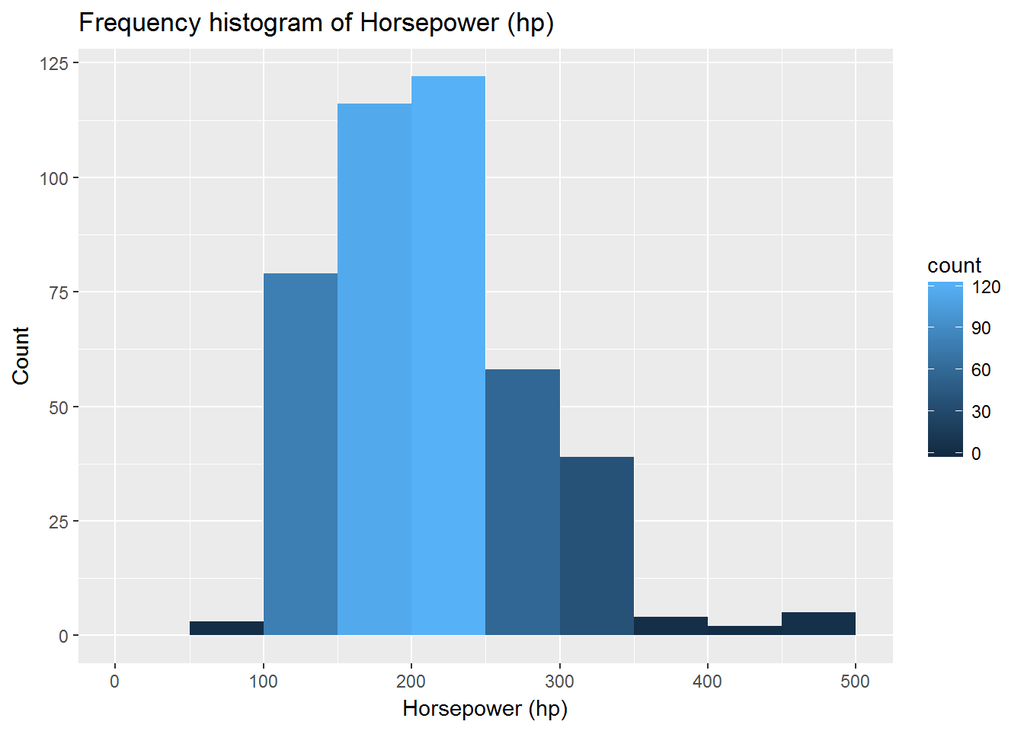

```r
ggplot(data1, aes(data1$x5)) +
    geom_histogram(breaks=seq(0, 500, by=50),
                                     aes(fill=..count..)) +
    scale_y_continuous(name = "Count") +
scale_x_continuous(name = "Horsepower (hp)") +
    ggtitle("Frequency histogram of Horsepower (hp)")
```

Tampak histogram *skew kanan*, sehingga variabel X5 tidak berdistribusi normal. Mayoritas mobil memiliki tenaga sekitar 200 hp.

## x6

Efisiensi bahan bakar dalam km per 100 liter pada jalanan dalam kota.

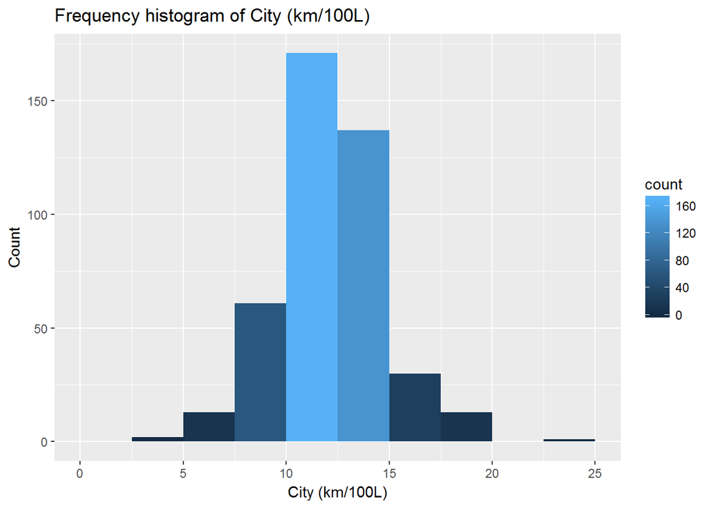

```r
ggplot(data1, aes(data1$x6)) +
    geom_histogram(breaks=seq(0, 25, by=2.5),
                                     aes(fill=..count..)) +
    scale_y_continuous(name = "Count") +
scale_x_continuous(name = "City (km/100L)") +
    ggtitle("Frequency histogram of City (km/100L)")
```

Tampak histogram simtetris sehingga variabel X6 berdistribusi normal. Mayoritas mobil mampu menempuh 10-13 km dengan 100 liter bahan bakar pada perjalanan dalam kota.

## x7

Efisiensi bahan bakar dalam km per 100 liter pada jalan bebas hambatan.

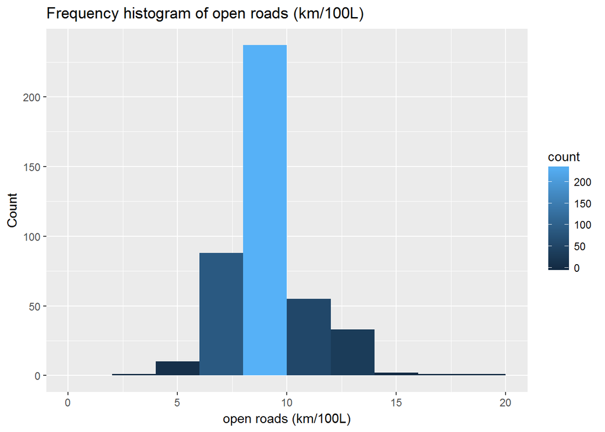

```r
ggplot(data1, aes(data1$x7)) +
    geom_histogram(breaks=seq(0, 20, by=2),
                                     aes(fill=..count..)) +
    scale_y_continuous(name = "Count") +
scale_x_continuous(name = "open roads (km/100L)") +
    ggtitle("Frequency histogram of open roads (km/100L)")
```

## x8

Berat mobil dalam satuan kilogram.

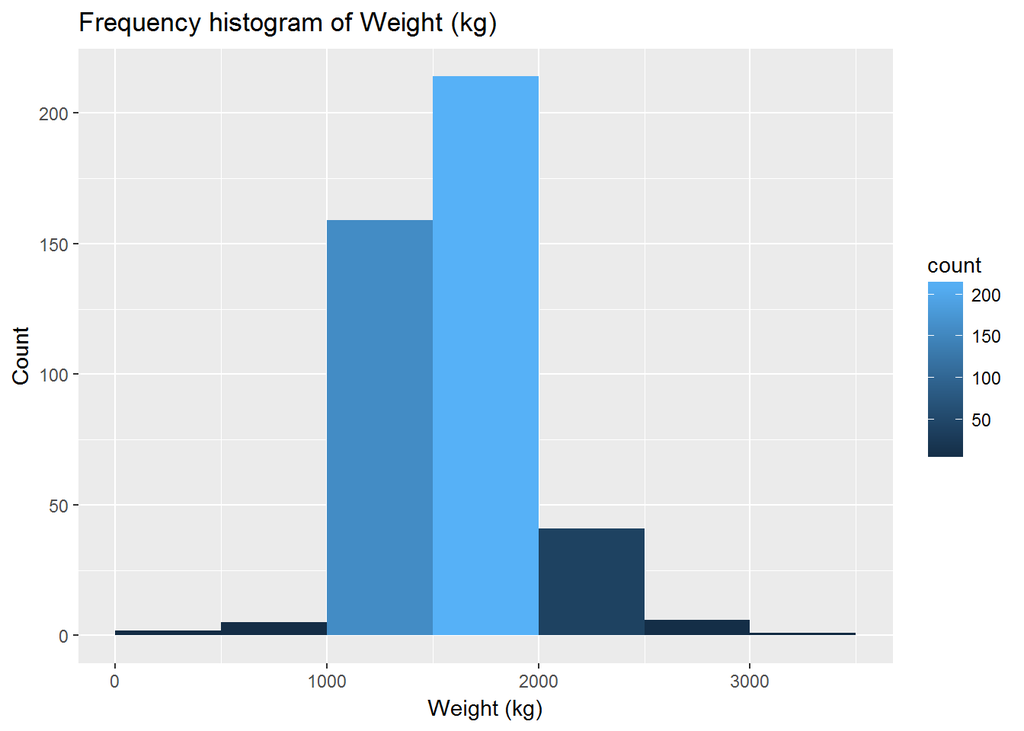

```r
ggplot(data1, aes(data1$x8)) +
    geom_histogram(breaks=seq(0, 3500, by=500),
                                     aes(fill=..count..)) +
    scale_y_continuous(name = "Count") +
scale_x_continuous(name = "Weight (kg)") +
    ggtitle("Frequency histogram of Weight (kg)")
```

Tampak histogram simetris, sehingga variabel X8 berdistribusi normal. Mayoritas mobil memiliki bobot 1500-2000 kilogram.

## x9

panjang *wheel base* mobil dalam satuan cm.

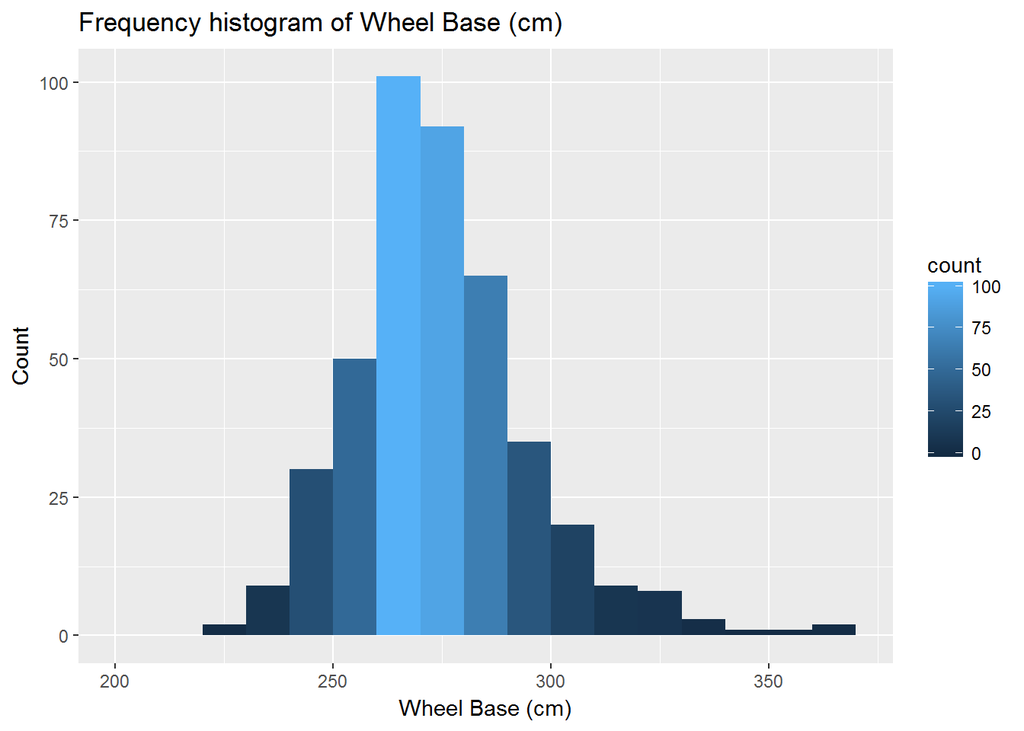

```r
ggplot(data1, aes(data1$x9)) +
    geom_histogram(breaks=seq(200, 375, by=10),
                                     aes(fill=..count..)) +
    scale_y_continuous(name = "Count") +
scale_x_continuous(name = "Wheel Base (cm)") +
    ggtitle("Frequency histogram of Wheel Base (cm)")
```

Tampak histogram simetris, sehingga variabel X9 berdistribusi normal. Mayoritas mobil memiliki panjang jarak sumbu roda 260-270 cm.

## x10

Panjang mobil dalam satuan cm.

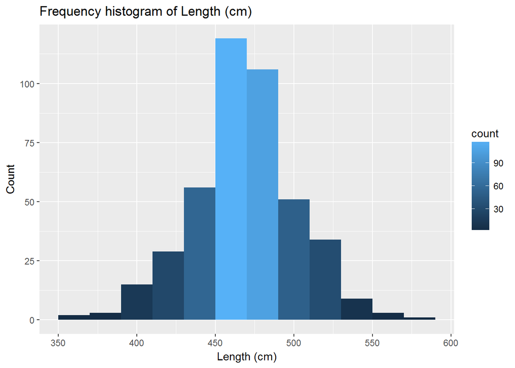

```r
ggplot(data1, aes(data1$x10)) +
    geom_histogram(breaks=seq(350, 600, by=20),
                                     aes(fill=..count..)) +
    scale_y_continuous(name = "Count") +
scale_x_continuous(name = "Length (cm)") +
    ggtitle("Frequency histogram of Length (cm)")
```

Tampak histogram simetris, sehingga variabel X10 berdistribusi normal. Mayoritas mobil memiliki panjang 450-470 cm.

## x11

Lebar mobil dalam satuan cm.

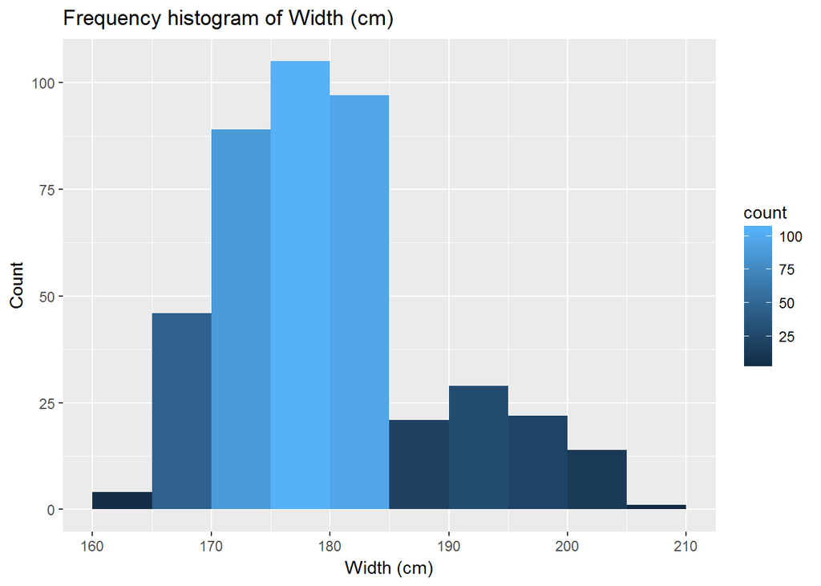

```r
ggplot(data1, aes(data1$x11)) +
    geom_histogram(breaks=seq(160, 210, by=5),
                                     aes(fill=..count..)) +
    scale_y_continuous(name = "Count") +
scale_x_continuous(name = "Width (cm)") +
    ggtitle("Frequency histogram of Width (cm)")
```

Tampak histogram *skew kanan*, sehingga variabel X11 tidak berdistribusi normal. Mayoritas mobil memiliki lebar 175-180 cm.

# *Principal Component Analysis* & *Factor Analysis*

### Asumsi

Uji kecukupan data digunakan untuk mengetahui layak tidaknya analisis faktor dilakukan. Uji kecukupan data dalam spesifikasi mobil di amerika dilakukan dengan menggunakan uji Kasier Kayer Olkin (KMO). Sedangkan uji korelasi yang digunakan untuk mengetahui apakah terdapat hubungan antar variabel dalam perhitungan spesifikasi mobil di amerika menggunakan metode uji Barrlett. Berikut ini adalah hasil dari perhitungan uji KMO dan uji Bartlett.

```r
KMO(data1)
```

```
## Kaiser-Meyer-Olkin factor adequacy
## Call: KMO(r = data1)
## Overall MSA =  0.85
## MSA for each item =
##   x1   x2   x3   x4   x5   x6   x7   x8   x9  x10  x11
## 0.76 0.75 0.88 0.90 0.95 0.83 0.77 0.93 0.87 0.77 0.89
```

Diketahui nilai KMO adalah 0.85 atau 85%. Hal itu menunjukkan terdapat korelasi antar variabel sehingga spesifikasi yang diberikan untuk mobil baru di Amerika sudah cukup untuk dilakukan analisis faktor.

```r
bartlett.test(data1)
```

```
##
##  Bartlett test of homogeneity of variances
##
## data:  data1
## Bartlett's K-squared = 49623, df = 10, p-value < 2.2e-16
```

### *Principal Component Analysis*

Analisis komponen utama digunakan untuk mengelompokkan variabel-variabel spesifikasi mobil baru di Amerika pada tahun 2004. Berikut adalah analisis dan pembahasan untuk analisis komponen utama.

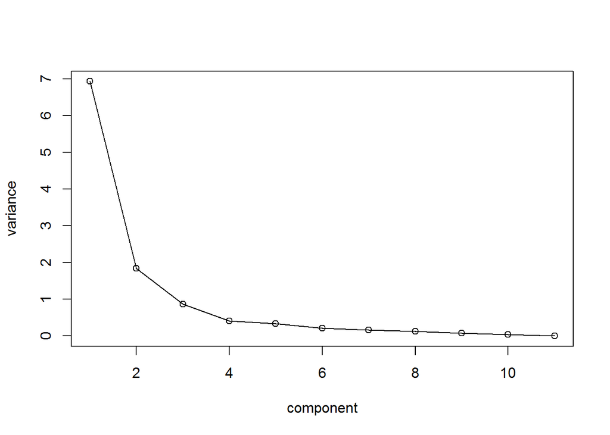

```r
plot(eigen(cor(data1))$value,ylab = "variance", xlab = "component")
lines(eigen(cor(data1))$values,)
```

Dari *Scree Plot* dapat dilihat bahwa dari titik pertama ke titik kedua menunjukkan garis yang turun secara curam. Sedangkan dari titik kedua ke titik ketiga hingga titik kesebelas menunjukkan garis garis yang turun secara landai. Sehingga hanya terdapat 2 komponen utama.

Penentuan jumlah faktor dapat dilihat juga dari eigenvalue. Berikut ini adalah eigenvalue dari data spesifikasi mobil amerika tahun 2004.

```r
korelasi=cor(data1)
p=ncol(data1)
sumvar <- sum(eigen(korelasi)$values)
pvar <- matrix(c(0),p,1)
cumvar <- matrix(c(0),p,1)
for(i in 1:p){
  pvar[i] <- eigen(korelasi)$values[i]/sumvar*100
  if (i == 1) {cumvar[i] <- pvar[i]}
  else
    cumvar[i] <- pvar[i] + cumvar[i-1]
}
disp1=cbind(eigen(cor(data1))$values,pvar,cumvar)
colnames(disp1)=c("Eigenvalues","Persentase Varians","Persentase Kumulatif")
disp1
```

```
##        Eigenvalues Persentase Varians Persentase Kumulatif
##  [1,] 6.9370458564        63.06405324             63.06405
##  [2,] 1.8390045765        16.71822342             79.78228
##  [3,] 0.8681358995         7.89214454             87.67442
##  [4,] 0.4093507133         3.72137012             91.39579
##  [5,] 0.3391314108         3.08301283             94.47880
##  [6,] 0.2127940670         1.93449152             96.41330
##  [7,] 0.1616465015         1.46951365             97.88281
##  [8,] 0.1226242445         1.11476586             98.99758
##  [9,] 0.0739912661         0.67264787             99.67022
## [10,] 0.0354707627         0.32246148             99.99268
## [11,] 0.0008047017         0.00731547            100.00000
```

```r
eigen(cor(data1))$vector[,1:2]
```

```
##             [,1]        [,2]
##  [1,] -0.2646517  0.49064813
##  [2,] -0.2625907  0.49350176
##  [3,] -0.3497498 -0.02378327
##  [4,] -0.3369479  0.07317646
##  [5,] -0.3231942  0.29016393
##  [6,] -0.3347531 -0.02868100
##  [7,] -0.2997084 -0.06432678
##  [8,] -0.3286430 -0.19051171
##  [9,] -0.2599333 -0.41226156
## [10,] -0.2452251 -0.37052770
## [11,] -0.2882719 -0.27766755
```

### *Factor Analysis*

Berdasarkan pada analisis komponen utama didapatkan bahwa banyaknya faktor yang diperlukan untuk mereduksi suatu variabel adalah sebanyak 2 faktor dan dilanjutkan dengan analisis faktor sebagai berikut.

```r
principal(data1,nfactors = 2,rotate="varimax")$loadings
```

```
##
## Loadings:
##     RC1   RC2
## x1        0.960
## x2        0.959
## x3  0.715 0.581
## x4  0.603 0.658
## x5  0.383 0.856
## x6  0.690 0.550
## x7  0.652 0.453
## x8  0.822 0.374
## x9  0.883
## x10 0.817
## x11 0.820 0.216
##
##                  RC1   RC2
## SS loadings    4.733 4.043
## Proportion Var 0.430 0.368
## Cumulative Var 0.430 0.798
```

Berdasarkan nilai komponen menunjukkan pengelompokan terhadap 11 variabel spesifikasi mobil baru di amerika berdasarkan kontribusi yang paling besar pada kedua komponen. Variabel yang masuk ke dalam komponen satu adalah variabel X<sub>3</sub>, X<sub>6</sub>, X<sub>7</sub>, X<sub>8,</sub> X<sub>9</sub>, X<sub>10</sub>, dan X<sub>11</sub> karena kontribusi yang paling besar diberikan pada komponen satu. Variabel yang masuk ke dalam komponen dua yaitu variabel X<sub>1</sub>, X<sub>2</sub>, x<sub>4</sub> dan X<sub>5</sub> dikarenakan nilai kontribusi terbesar pada komponen dua.

sehingga faktor baru yang terbentuk adalah sebagai berikut

| Variabel | Keterangan Variabel | Nama Faktor Baru |
| --- | --- | --- |
| x3 | *Engine Size (Litres)* | Eksternal |
| x6 | *CIty* (km/100L) | Eksternal |
| x7 | *Open Road* (km/100L) | Eksternal |
| x8 | *Wieght* (kg) | Eksternal |
| x9 | *Wheel Base* (cm) | Eksternal |
| x10 | *Length* (cm) | Eksternal |
| x11 | *Width* (cm) | Eksternal |
| x1 | *Retail Price* ($US) | Internal |
| x2 | *Cost Price* ($US) | Internal |
| x4 | *Number of Cylinders* | Internal |
| x5 | *Horsepower* (hp) | Internal |